# PSL (S21) Coding Assignment 2

02/05/2021

## Load Data

You can ignore the code snippet below and start your code with loading “Coding2_myData.csv”

```r
library(MASS)
myData = Boston
names(myData)[14] = "Y"
iLog = c(1, 3, 5, 6, 8, 9, 10, 14);
myData[, iLog] = log(myData[, iLog]);
myData[, 2] = myData[, 2] / 10;
myData[, 7] = myData[, 7]^2.5 / 10^4
myData[, 11] = exp(0.4 * myData[, 11]) / 1000;
myData[, 12] = myData[, 12] / 100;
myData[, 13] = sqrt(myData[, 13]);
write.csv(myData, file = "Coding2_myData.csv",
          row.names = FALSE)

# After preparing the dataset, remove all objects and the attached MASS library
rm(list=objects())
detach("package:MASS")
```

**You can start here.**

```r
myData = read.csv("Coding2_myData.csv")
X = as.matrix(myData[, -14])
y = myData$Y
dim(X)
```

```
[1] 506  13
```

## CD for Lasso

Implement the Coordinate Descent algorithm for Lasso. Some part of the function `MyLasso` is blocked here, but your submission should include all code used to produce your results.

```r
MyLasso = function(X, y, lam.seq, maxit = 500) {

    # X: n-by-p design matrix without the intercept
    # y: n-by-1 response vector
    # lam.seq: sequence of lambda values
    # maxit: number of updates for each lambda
    # Center/Scale X
    # Center y

    n = length(y)
    p = dim(X)[2]
    nlam = length(lam.seq)

    ##############################
    # YOUR CODE:
    # Record the corresponding means and scales
    # For example,
    # y.mean = mean(y)
    # Xs = centered and scaled X
    ##############################

    # Initilize coef vector b and residual vector r
    b = rep(0, p)
    r = y
    B = matrix(nrow = nlam, ncol = p + 1)

    # Triple nested loop
    for (m in 1:nlam) {
        lam = 2 * n * lam.seq[m]
        for (step in 1:maxit) {
            for (j in 1:p) {
                r = r + (Xs[, j] * b[j])
                b[j] = one_var_lasso(r, Xs[, j], lam)
                r = r - Xs[, j] * b[j]
            }
        }
        B[m, ] = c(0, b)
    }

    ##############################
    # YOUR CODE:
    # Scale back the coefficients;
    # Update the intercepts stored in B[, 1]
    ##############################
}
```

## Some Technical Details

- We use the following function to solve the Lasso estimate for $\beta_j$ given other coefficients fixed; see the derivation in Coding2.pdf.

```r
one_var_lasso = function(r, x, lam) {
    xx = sum(x^2)
    xr = sum(r * x)
    b = (abs(xr) - lam/2)/xx
    b = sign(xr) * ifelse(b > 0, b, 0)
    return(b)
}
```

- `glmnet` standardizes the data using a different definition of “standard deviation”, which is divided by **n**, while the command `sd(z)` in R divides the sum of squares by **(n-1)** where z is a n-by-1 data vector. We suggest to use `sd(z) * sqrt((n-1)/n)` to compute the standard deviation of a data vetor used in `myLasso`, since
  $$\sqrt{\frac{\sum_i (z_i - \text{z.mean})^2}{n}} = \sqrt{\frac{\sum_i (z_i - \text{z.mean})^2}{n-1}} \cdot \sqrt{\frac{n-1}{n}} = \text{sd(z)} \cdot \sqrt{\frac{n-1}{n}}.$$
- Why we need to scale the lambda value by (2n) in `lam = 2*n*lam.seq[m]`? As detailed in Coding2.pdf, the `one_var_lasso` function is derived based on objective function
  $$\text{RSS} + \lambda \cdot | \beta|,$$
  while the objective function used in `glmnet` is
  $$\frac{1}{2n} \text{RSS} + \lambda | \beta| \ \propto \ \text{RSS} + 2 n \lambda | \cdot \beta|$$
  So to compare results from the two algorithms on an equal footing, we need to scale our lambda value by (2n).

## Test Your Code

Test your code with the following lambda sequence. The 80 sets of coefficients (including the intercept) are stored in a 14-by-80 matrix `myout`.

```r
lam.seq = exp(seq(-1, -8, length.out = 80))
myout = MyLasso(X, y, lam.seq, maxit = 100)
rownames(myout) = c("Intercept", colnames(X))
dim(myout)
```

```
[1] 14 80
```

Produce the path plot for the 13 non-intercept coefficients with the x-coordinate to be the lambda values in log-scale.

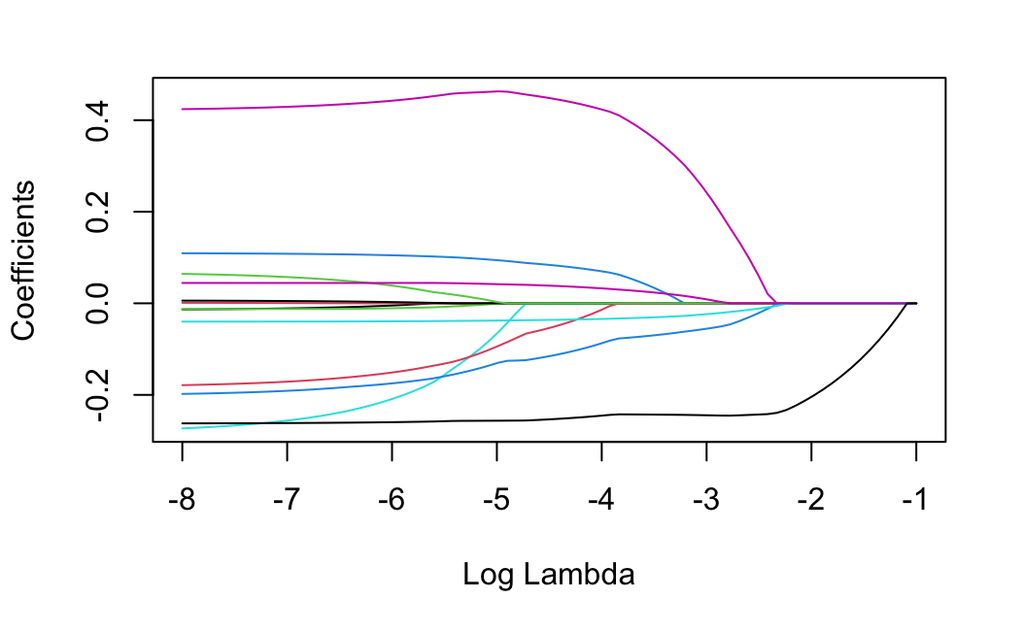

```r
x.index = log(lam.seq)
beta = myout[-1, ]  # beta is a 13-by-80 matrix
matplot(x.index, t(beta),
        xlim = c(min(x.index), max(x.index)),
        lty = 1,
        xlab = "Log Lambda",
        ylab = "Coefficients",
        type="l",
        lwd = 1)
```

```r
# You can add variable names to each path
# var.names = colnames(X)
# nvar = length(var.names)
# xpos = rep(min(x.index), nvar)
# ypos = beta[, ncol(beta)]
# text(xpos, ypos, var.names, cex=0.5, pos=2)
```

## Check the Accuracy

Compare the accuracy of your algorithm against the output from `glmnet`. The maximum difference between the two coefficient matrices should be less than 0.005.

```r
library(glmnet)
lasso.fit = glmnet(X, y, alpha = 1, lambda = lam.seq)
# coef(lasso.fit)
write.csv(as.matrix(coef(lasso.fit)), file = "Coding2_lasso_coefs.csv",
          row.names = FALSE)
```

```r
max(abs(coef(lasso.fit) - myout))
```

```
[1] 0.004645317
```

Your plot should look the plot from `glmnet`

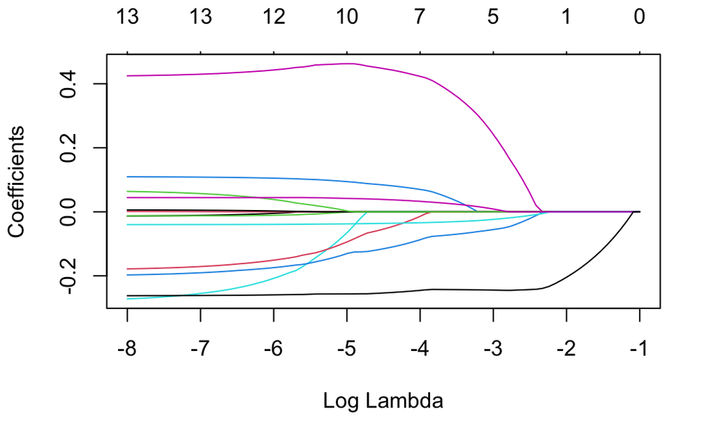

```r
plot(lasso.fit, xvar = "lambda")
```